# Visualización de Datos PEC3

## 1.5 Visualización: WordCloud Tweets

```r
# Creamos un corpus de texto
corpus <- Corpus(VectorSource(tweets_data$Text))

# Realizamos el preprocesamiento de texto
corpus <- tm_map(corpus, content_transformer(tolower))
corpus <- tm_map(corpus, removePunctuation)
corpus <- tm_map(corpus, removeNumbers)
corpus <- tm_map(corpus, removeWords, c(stopwords("en"), "DELL", "dell"))
corpus <- tm_map(corpus, stripWhitespace)
```

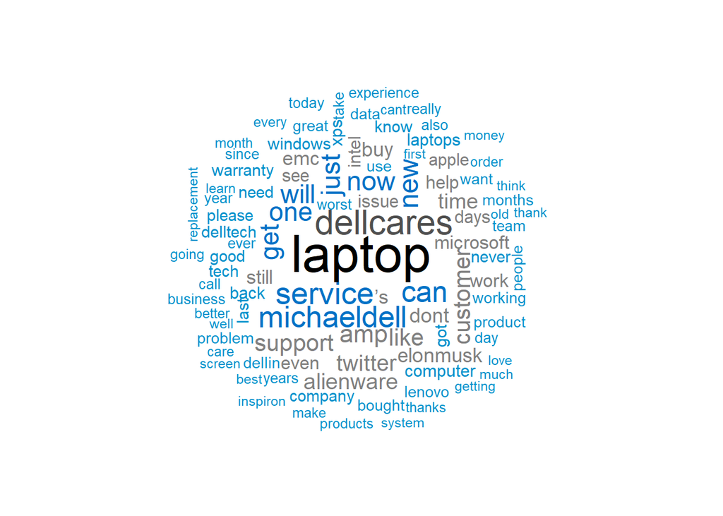

```r
# Creamos un documento de términos
dtm <- TermDocumentMatrix(corpus)

# Extraemos la matriz de términos
terms <- as.matrix(dtm)

# Calculamos la frecuencia de las palabras
word_freqs <- sort(rowSums(terms), decreasing = TRUE)

# Definimos una paleta de colores personalizada, hemos obtado por una con similitud a DELL
custom_colors <- c("#0092CC", "#808080","#0072C6", "#4F4F4F", "#000000")  # Azul, gris oscuro, negro

# Creamos la nube de palabras
wordcloud(words = names(word_freqs), freq = word_freqs, min.freq = 5, max.words = 100, random.order = FALSE, scale = c(3, 0.5), colors = custom_colors )
```

```r
# Filtramos solo los tweets con sentimiento negativo
negative_tweets <- subset(tweets_data, sentiment == "negative")

# Creamos un corpus de texto
corpus_negative <- Corpus(VectorSource(negative_tweets$Text))

# Realizamos el preprocesamiento de texto
corpus_negative <- tm_map(corpus_negative, content_transformer(tolower))
corpus_negative <- tm_map(corpus_negative, removePunctuation)
corpus_negative <- tm_map(corpus_negative, removeNumbers)
corpus_negative <- tm_map(corpus_negative, removeWords, c(stopwords("en"), "DELL", "dell"))
corpus_negative <- tm_map(corpus_negative, stripWhitespace)
```

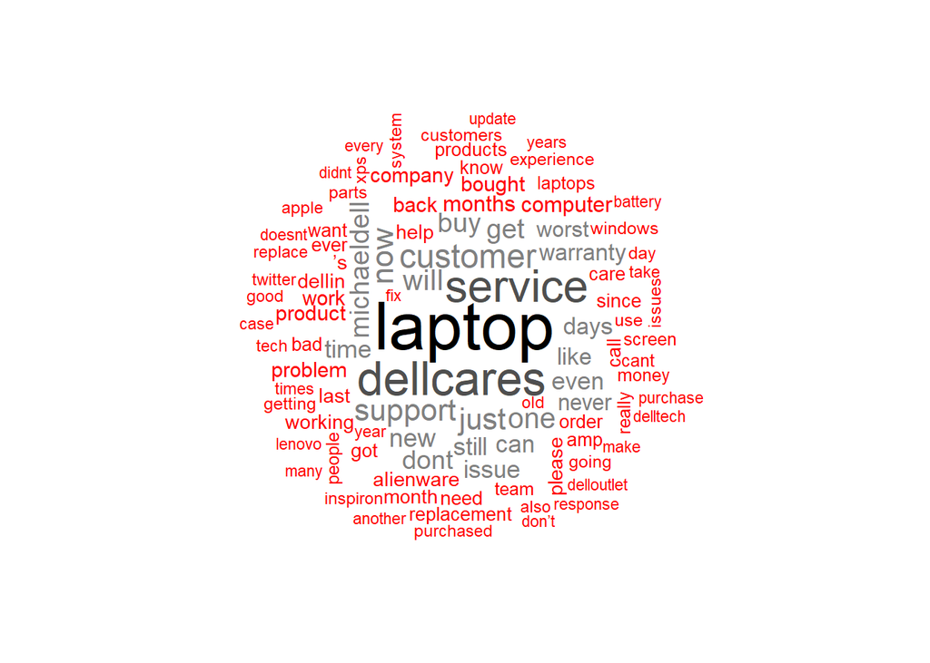

```r
# Creamos un documento de términos
dtm_negative <- TermDocumentMatrix(corpus_negative)

# Extraemos la matriz de términos
terms_negative <- as.matrix(dtm_negative)

# Calculamos la frecuencia de las palabras
word_freqs_negative <- sort(rowSums(terms_negative), decreasing = TRUE)

# Definimos una paleta de colores personalizada
negative_custom_colors <- c("red", "#808080", "#FF313A", "#4F4F4F", "#000000")  # Rojo, gris oscuro, rojo oscuro, gris oscuro, negro

# Creamos la nube de palabras
wordcloud(words = names(word_freqs_negative), freq = word_freqs_negative, min.freq = 5, max.words = 100, random.order = FALSE, scale = c(3, 0.5), colors = negative_custom_colors )
```

```r
# Filtramos solo los tweets con sentimiento negativo
positive_tweets <- subset(tweets_data, sentiment == "positive")

# Creamos un corpus de texto
corpus_positive <- Corpus(VectorSource(positive_tweets$Text))

# Realizamos el preprocesamiento de texto
corpus_positive <- tm_map(corpus_positive, content_transformer(tolower))
corpus_positive <- tm_map(corpus_positive, removePunctuation)
corpus_positive <- tm_map(corpus_positive, removeNumbers)
corpus_positive <- tm_map(corpus_positive, removeWords, c(stopwords("en"), "DELL", "dell"))
corpus_positive <- tm_map(corpus_positive, stripWhitespace)
```

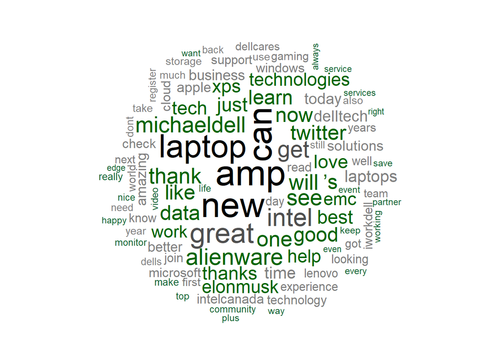

```r
# Creamos un documento de términos
dtm_positive <- TermDocumentMatrix(corpus_positive)

# Extraemos la matriz de términos
terms_positive <- as.matrix(dtm_positive)

# Calculamos la frecuencia de las palabras
word_freqs_positive <- sort(rowSums(terms_positive), decreasing = TRUE)


positive_custom_colors <- c("#116433", "#808080", "#006400", "#4F4F4F", "#000000")

# Creamos la nube de palabras

wordcloud(words = names(word_freqs_positive), freq = word_freqs_positive, min.freq = 10, max.words = 100, random.order = FALSE, scale = c(3, 0.3), colors = positive_custom_colors)
```

En estos wordclouds si que vemos algunas palabras que se repiten en todas las categorias, general, negativa y o positiva, como es laptop, por lo que podria indicarnos que la mayoria de tweets hacen referencia a la gama de laptops.

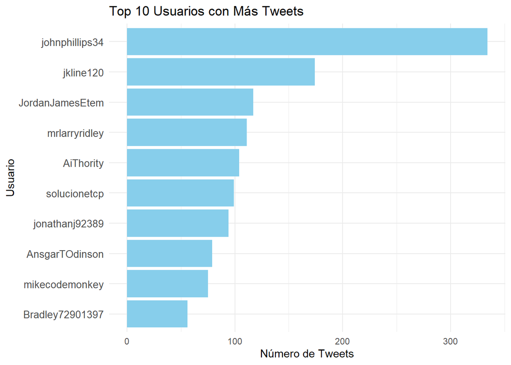

```r
# Crear un gráfico de barras para mostrar los 10 usuarios con más tweets
top_users <- tweets_data %>%
  group_by(Username) %>%
  summarize(TotalTweets = n()) %>%
  arrange(desc(TotalTweets)) %>%
  head(10)

# Crear un gráfico de barras horizontales para los 10 usuarios con más tweets
ggplot(top_users, aes(x = TotalTweets, y = reorder(Username, TotalTweets))) +
  geom_bar(stat = "identity", fill = "skyblue") +
  labs(title = "Top 10 Usuarios con Más Tweets", x = "Número de Tweets", y = "Usuario") +
  theme_minimal() +
  theme(axis.text.y = element_text(size = 10))  # Ajustar el tamaño del texto en el eje y
```

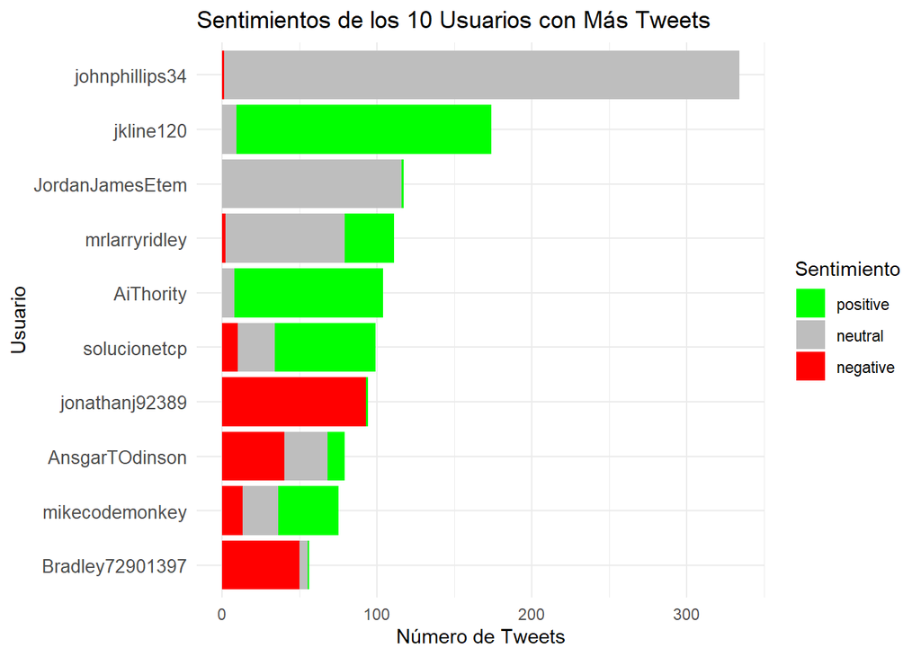

```r
# Filtramos los tweets de los 10 usuarios principales
top_10_tweets <- tweets_data %>%
  filter(Username %in% top_users$Username)


# Creamos una columna "TotalTweets" con el número total de tweets por usuario
top_10_tweets <- top_10_tweets %>%
  group_by(Username) %>%
  mutate(TotalTweets = n())

# Convertimos la columna "sentiment" a factor
top_10_tweets$sentiment <- factor(top_10_tweets$sentiment, levels = c("positive", "neutral", "negative"))

# Organizamos top_10_tweets por el número total de tweets de mayor a menor
top_10_tweets <- top_10_tweets[order(-top_10_tweets$TotalTweets), ]

# Creamos un gráfico de barras apiladas para mostrar por sentimientos de los 10 usuarios con más tweets
ggplot(top_10_tweets, aes(y = reorder(Username, TotalTweets), fill = sentiment)) +
  geom_bar() +
  labs(title = "Sentimientos de los 10 Usuarios con Más Tweets", x = "Número de Tweets", y = "Usuario", fill = "Sentimiento") +
  theme_minimal() +
  theme(axis.text.y = element_text(size = 10)) + # Ajustar el tamaño del texto en el eje y
  scale_fill_manual(values = c("positive" = "green", "neutral" = "grey", "negative" = "red"))
```

Y en este ultimo punto, el mayor twittero acerca de la marca no habla ni bien ni mal, es bastante neutral, pero sin embargo el segundo habla de forma positiva y no es hasta la 7ª persona con mas tweets que habla mayormente mal de la marca y comenta cosas positivas tambien de la misma.

Con estos datos hemos realizado una infografia:  
https://infogram.com/pec3_visualizacion-de-datos-1h984wo9r85jd6p?live